# Lab 4

Brandon Krcil

2020-02-07

# Task 1

```r
knitr::opts_chunk$set(echo = TRUE)
```

```r
getwd()
```

```
## [1] "/Users/FromundaCheese/Desktop/RPACKAGES/math4753/R"
```

# Task 2

```r
spruce.df = read.csv("SPRUCE.csv")
 myread=function(csv){
  fl=paste(dird,csv,sep="")
  read.table(fl,header=TRUE,sep=",")
 }
 tail(spruce.df)
```

```
##    BHDiameter Height
## 31       17.7   19.9
## 32       20.7   19.4
## 33       21.0   20.4
## 34       13.3   15.5
## 35       15.9   17.6
## 36       22.9   19.2
```

# Task 3

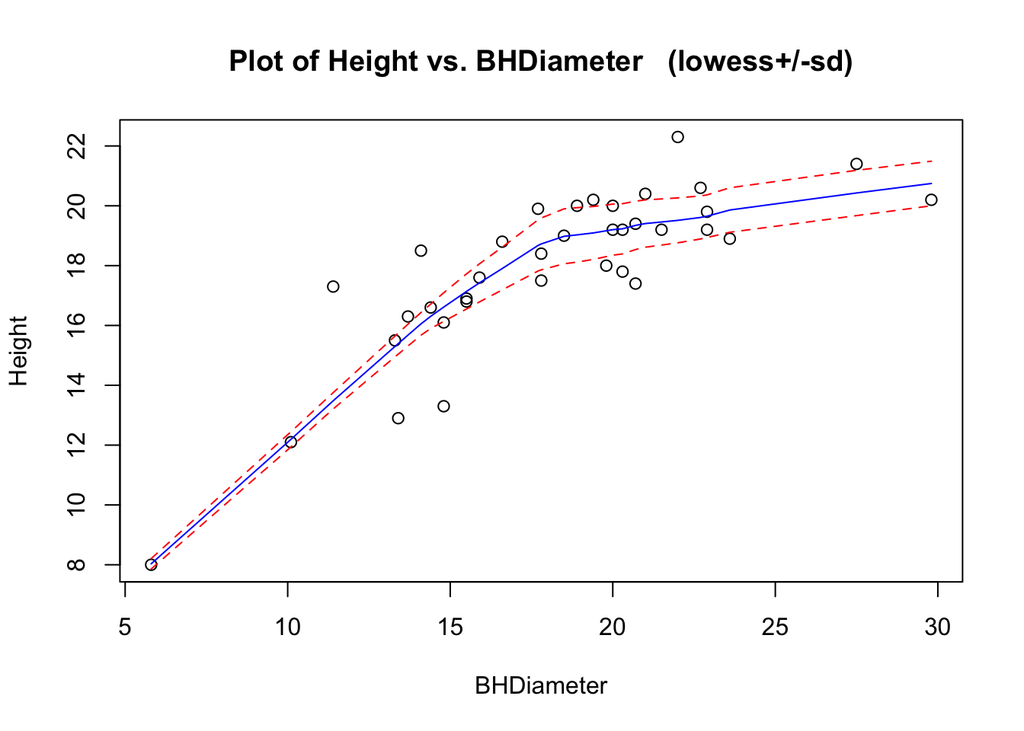

```r
library(s20x)

trendscatter(Height~BHDiameter,f=0.5,data=spruce.df)
```

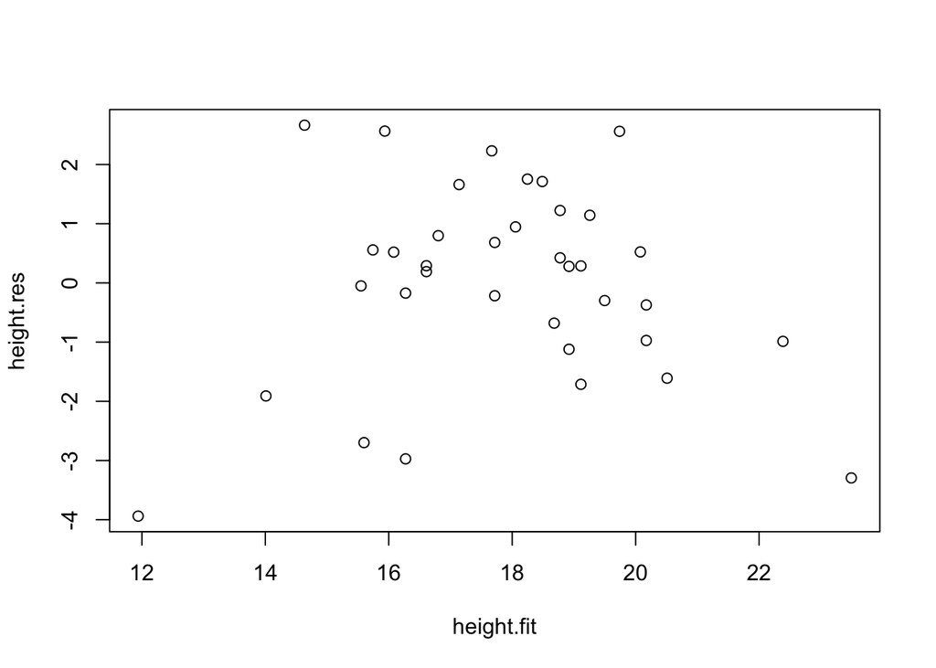

```r
spruce.lm=with(spruce.df,lm(Height~BHDiameter))
height.res=residuals(spruce.lm)
height.fit=fitted(spruce.lm)
plot(height.fit,height.res)
```

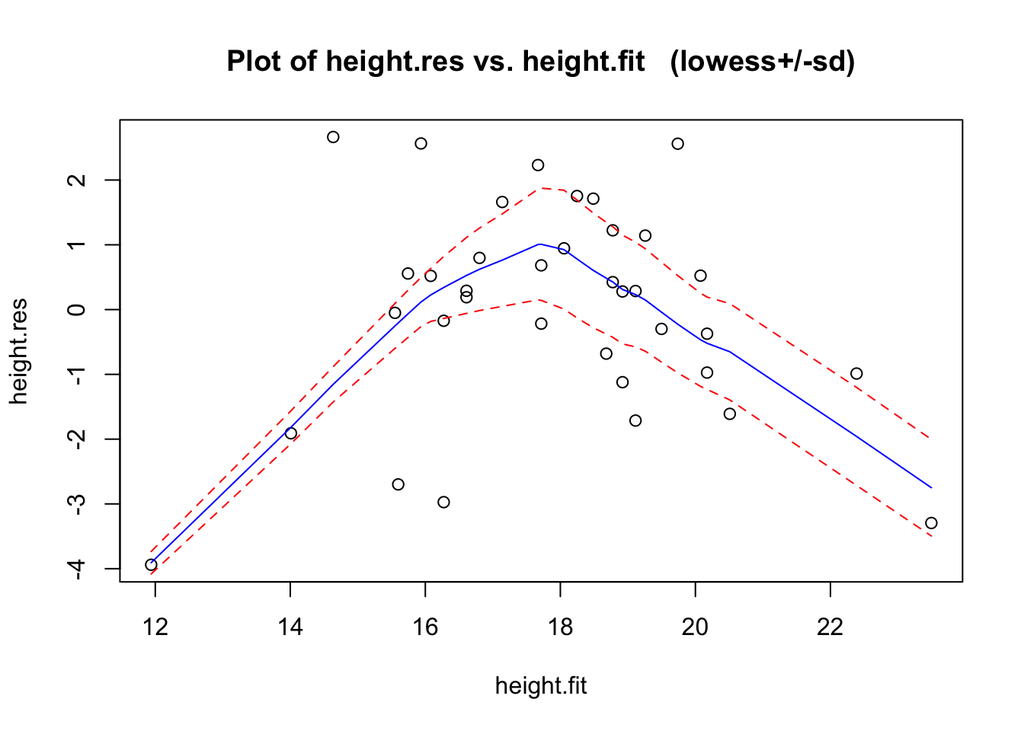

```r
library(s20x)
trendscatter(height.res~height.fit)
```

> What shape is seen in the plot? Compare it with the curve made with the trendscatter function. Answer: This curve is a lot more bell shaped than the first one that was plotted, and trends down instead of continually going upwards and represents the data better than the linear function from Lab 3.

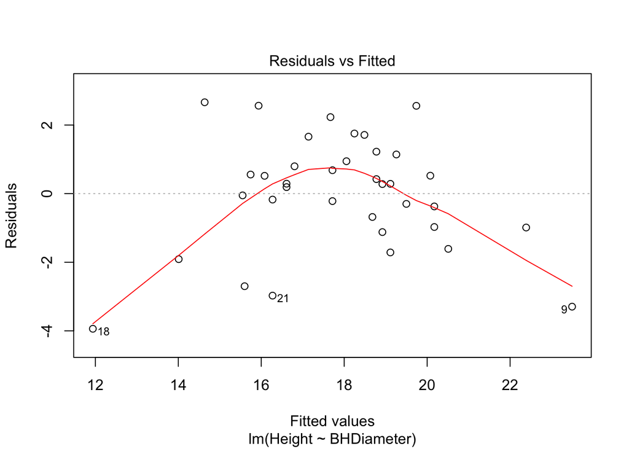

```r
plot(spruce.lm, which =1)
```

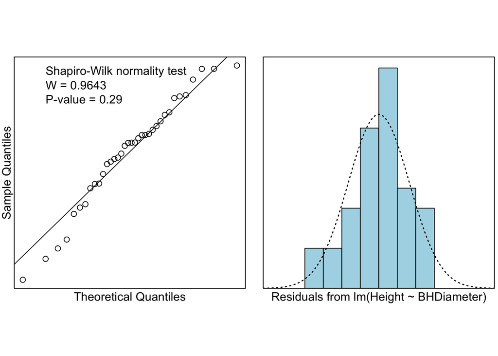

```r
normcheck(spruce.lm,shapiro.wilk = TRUE)
```

> What is the pvalue for the Shapiro-Wilk test? What is the NULL hypothesis in this case?

> Write a sentence outlining your conclusions concerning the validity of applying the straight line to this data set.

# Task 4

```r
quad.lm=lm(Height~BHDiameter + I(BHDiameter^2),data=spruce.df)
summary(quad.lm)
```

```
##
## Call:
## lm(formula = Height ~ BHDiameter + I(BHDiameter^2), data = spruce.df)
##
## Residuals:
##     Min      1Q  Median      3Q     Max
## -3.2966 -0.6245 -0.0707  0.7442  3.2541
##
## Coefficients:
##                  Estimate Std. Error t value Pr(>|t|)
## (Intercept)      0.860896   2.205022   0.390 0.698731
## BHDiameter       1.469592   0.243786   6.028 8.88e-07 ***
## I(BHDiameter^2) -0.027457   0.006635  -4.138 0.000227 ***
## ---
## Signif. codes:  0 '***' 0.001 '**' 0.01 '*' 0.05 '.' 0.1 ' ' 1
##
## Residual standard error: 1.382 on 33 degrees of freedom
## Multiple R-squared:  0.7741, Adjusted R-squared:  0.7604
## F-statistic: 56.55 on 2 and 33 DF,  p-value: 2.182e-11
```

```r
add1(spruce.lm,.~.+I(BHDiameter^2))
```

```
## Single term additions
##
## Model:
## Height ~ BHDiameter
##                 Df Sum of Sq    RSS    AIC
## <none>                       95.703 39.198
## I(BHDiameter^2)  1    32.696 63.007 26.150
```

```r
anova(spruce.lm)
```

```
## Analysis of Variance Table
##
## Response: Height
##            Df  Sum Sq Mean Sq F value    Pr(>F)
## BHDiameter  1 183.245 183.245  65.101 2.089e-09 ***
## Residuals  34  95.703   2.815
## ---
## Signif. codes:  0 '***' 0.001 '**' 0.01 '*' 0.05 '.' 0.1 ' ' 1
```

```r
anova(quad.lm)
```

```
## Analysis of Variance Table
##
## Response: Height
##                 Df  Sum Sq Mean Sq F value    Pr(>F)
## BHDiameter       1 183.245 183.245  95.975 2.701e-11 ***
## I(BHDiameter^2)  1  32.696  32.696  17.125 0.0002269 ***
## Residuals       33  63.007   1.909
## ---
## Signif. codes:  0 '***' 0.001 '**' 0.01 '*' 0.05 '.' 0.1 ' ' 1
```

```r
anova(spruce.lm,quad.lm)
```

```
## Analysis of Variance Table
##
## Model 1: Height ~ BHDiameter
## Model 2: Height ~ BHDiameter + I(BHDiameter^2)
##   Res.Df    RSS Df Sum of Sq      F    Pr(>F)
## 1     34 95.703
## 2     33 63.007  1    32.696 17.125 0.0002269 ***
## ---
## Signif. codes:  0 '***' 0.001 '**' 0.01 '*' 0.05 '.' 0.1 ' ' 1
```

```r
cubic.lm=lm(Height~BHDiameter + I(BHDiameter^2)+I(BHDiameter^3),data=spruce.df)
anova(cubic.lm)
```

```
## Analysis of Variance Table
##
## Response: Height
##                 Df  Sum Sq Mean Sq F value    Pr(>F)
## BHDiameter       1 183.245 183.245 93.5555 5.089e-11 ***
## I(BHDiameter^2)  1  32.696  32.696 16.6929 0.0002751 ***
## I(BHDiameter^3)  1   0.329   0.329  0.1681 0.6845151
## Residuals       32  62.678   1.959
## ---
## Signif. codes:  0 '***' 0.001 '**' 0.01 '*' 0.05 '.' 0.1 ' ' 1
```

```r
add1(quad.lm,.~.+I(BHDiameter^3))
```

```
## Single term additions
##
## Model:
## Height ~ BHDiameter + I(BHDiameter^2)
##                 Df Sum of Sq    RSS    AIC
## <none>                       63.007 26.150
## I(BHDiameter^3)  1    0.3293 62.678 27.961
```

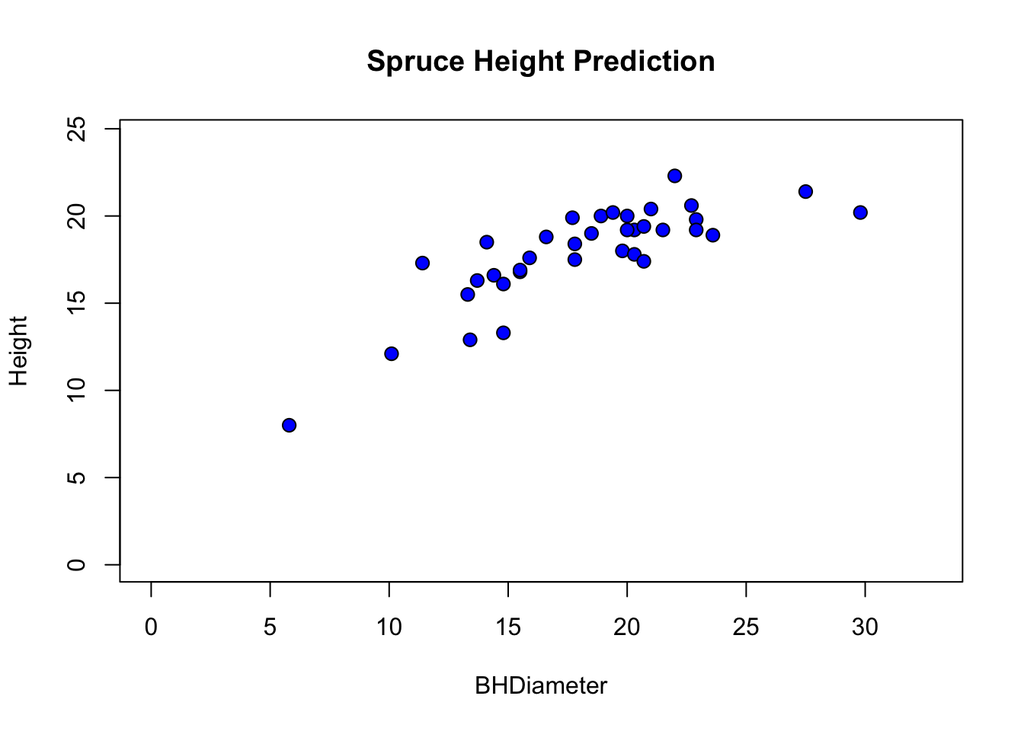

```r
plot(Height~BHDiameter,bg="Blue",pch=21,cex=1.2,
     ylim=c(0,1.1*max(Height)), xlim=c(0,1.1*max(BHDiameter)),
     main="Spruce Height Prediction", data=spruce.df)
```

```r
plot(Height~BHDiameter,bg="Blue",pch=21,cex=1.2,
ylim=c(0,max(Height)),xlim=c(0,max(BHDiameter)),
main="Spruce height prediction",data=spruce.df)

coef(quad.lm)
```

```
##     (Intercept)      BHDiameter I(BHDiameter^2)
##      0.86089580      1.46959217     -0.02745726
```

```r
names(quad.lm)
```

```
##  [1] "coefficients"  "residuals"     "effects"       "rank"
##  [5] "fitted.values" "assign"        "qr"            "df.residual"
##  [9] "xlevels"       "call"          "terms"         "model"
```

```r
quad.lm$coef[2]
```

```
## BHDiameter
##   1.469592
```

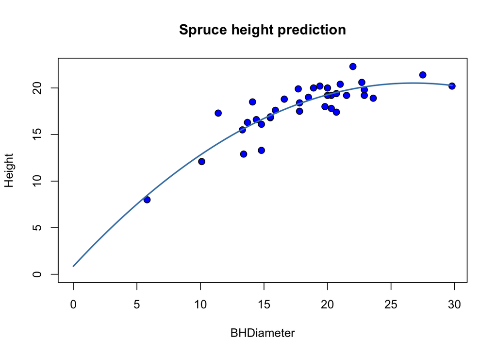

```r
myplot=function(x){
 0.86089580 +1.46959217*x  -0.02745726*x^2
 }

curve(myplot, lwd=2, col="steelblue",add=TRUE)
```

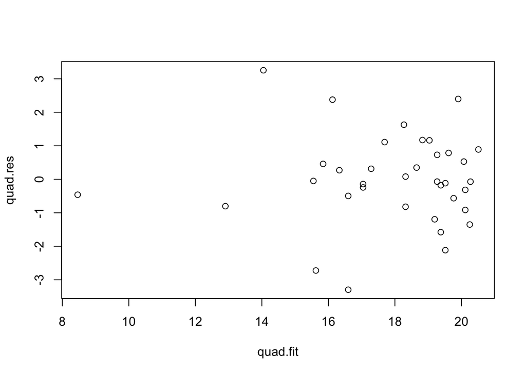

```r
quad.res=residuals(quad.lm)
quad.fit=fitted(quad.lm)
plot(quad.fit,quad.res)
```

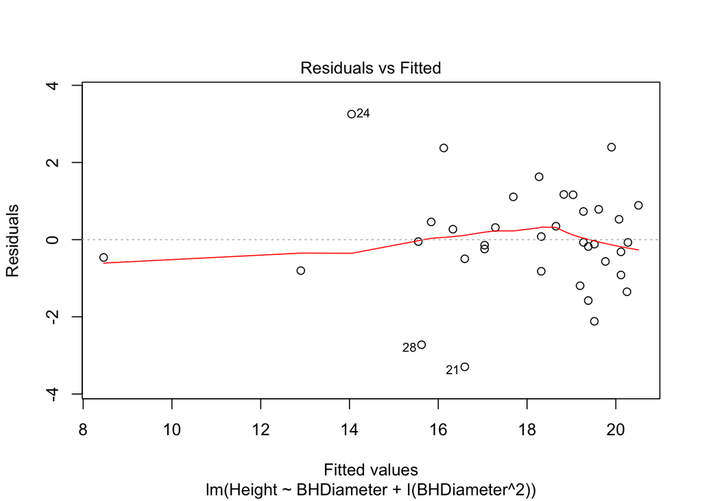

```r
plot(quad.lm, which=1)
```

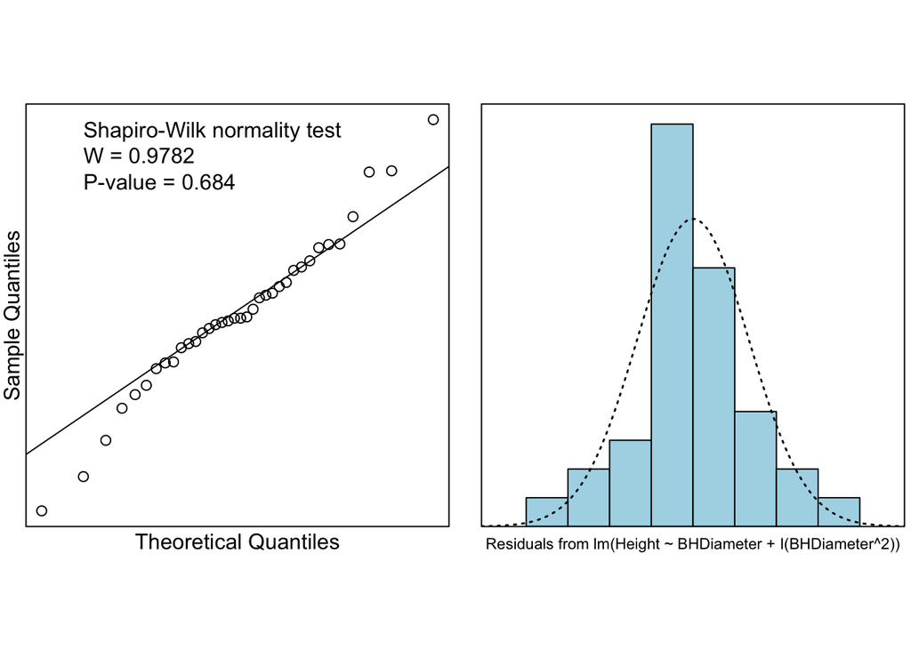

```r
normcheck(quad.lm,shapiro.wilk = TRUE)
```

> What is the value of the p-value in the Shapiro-Wilk test? What do you conclude?

> The p-value is 0.684. It can be concluded that a quadratic function is a good estimate of the data due to the null hypothesis.

# Task 5

```r
summary(quad.lm)
```

```
##
## Call:
## lm(formula = Height ~ BHDiameter + I(BHDiameter^2), data = spruce.df)
##
## Residuals:
##     Min      1Q  Median      3Q     Max
## -3.2966 -0.6245 -0.0707  0.7442  3.2541
##
## Coefficients:
##                  Estimate Std. Error t value Pr(>|t|)
## (Intercept)      0.860896   2.205022   0.390 0.698731
## BHDiameter       1.469592   0.243786   6.028 8.88e-07 ***
## I(BHDiameter^2) -0.027457   0.006635  -4.138 0.000227 ***
## ---
## Signif. codes:  0 '***' 0.001 '**' 0.01 '*' 0.05 '.' 0.1 ' ' 1
##
## Residual standard error: 1.382 on 33 degrees of freedom
## Multiple R-squared:  0.7741, Adjusted R-squared:  0.7604
## F-statistic: 56.55 on 2 and 33 DF,  p-value: 2.182e-11
```

> What is the value of $\hat{\beta_0}$?

> Answer: The value of $\hat{\beta_0}$ is 0.860896.

> Question: What is the value of$\hat{\beta_1}$?

> Answer: 1.469592

> Question: What is the value of$\hat{\beta_2}$?

> Answer: -0.027457

> Interval estimates for $\beta_0$,$\beta_1$,$\beta_2$.

> Answer: 3.065918 to -1.344126, 1.713378 to 0.98202, -0.020822 to -0.034092

> Question: Write an equation of the fitted line.

> Answer: $y= -0.027x^2 + 1.469x + 0.861$

```r
predict(quad.lm, data.frame(BHDiameter=c(15,18,20)))
```

```
##        1        2        3
## 16.72690 18.41740 19.26984
```

> Question: What is the value of multiple R^2? Compare it with the previous model.

> Answer: 0.7741. The r^2 of the new data is higher and therefore more accurate.

> Question: Make use of adjusted R squared to compare models to determine which is “better”.

> Answer: The second one is better because it is higher at 0.7604, and it takes into account more predictors than the regular r squared.

> Question: What does ( multiple R^2) mean in this case?

> Answer: the quadratic one takes another variable into account to see which is better. So the quadratic is more accurate.

> Question: What does ( multiple R^2) mean in this case?

> Answer: the quadratic one takes another variable into account to see which is better. So the quadratic is more accurate.

> Question: Which model explains the most variability in the Height?

> Answer: The quadratic explains the most variance in height, due to the numbers shown in the analysis of the table and the higher r values.

```r
anova(quad.lm)
```

```
## Analysis of Variance Table
##
## Response: Height
##                 Df  Sum Sq Mean Sq F value    Pr(>F)
## BHDiameter       1 183.245 183.245  95.975 2.701e-11 ***
## I(BHDiameter^2)  1  32.696  32.696  17.125 0.0002269 ***
## Residuals       33  63.007   1.909
## ---
## Signif. codes:  0 '***' 0.001 '**' 0.01 '*' 0.05 '.' 0.1 ' ' 1
```

```r
anova(spruce.lm)
```

```
## Analysis of Variance Table
##
## Response: Height
##            Df  Sum Sq Mean Sq F value    Pr(>F)
## BHDiameter  1 183.245 183.245  65.101 2.089e-09 ***
## Residuals  34  95.703   2.815
## ---
## Signif. codes:  0 '***' 0.001 '**' 0.01 '*' 0.05 '.' 0.1 ' ' 1
```

> Use anova() and compare the two models. Paste anova output here and give your conclusion underneath. Find TSS, record it here Find MSS, record it here Find RSS, record it here What is the value of MSS/TSS?

```r
height.qfit=fitted(quad.lm)
RSS=with(spruce.df, sum((Height-height.qfit)^2))
RSS
```

```
## [1] 63.00683
```

```r
MSS = with(spruce.df, sum((height.qfit-mean(Height))^2))
MSS
```

```
## [1] 215.9407
```

```r
TSS = with(spruce.df, sum((Height-mean(Height))^2))
TSS
```

```
## [1] 278.9475
```

```r
MSS/TSS
```

```
## [1] 0.7741266
```

# Task 6

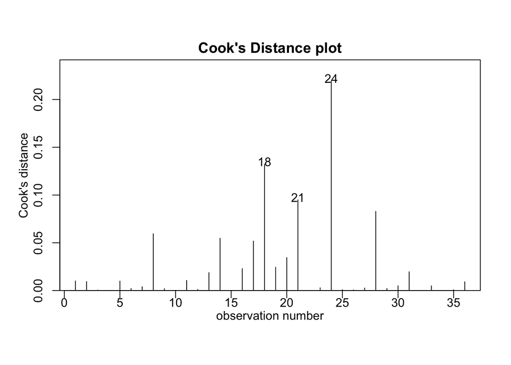

```r
cooks20x(quad.lm)
```

> Cook’s distance is used in analysis. It is an estimate of the influence of a data point when performing regression analysis. Points with a large cooks distance/residuals should be looked at.

> Question: What does cooks distance for the quadratic model and data tell you?

> Answer: 18, 21, and 24 points should be examined because they are large enough to be outliers.

```r
quad2.lm=lm(Height~BHDiameter + I(BHDiameter^2) , data=spruce.df[-24,])
summary(quad2.lm)
```

```
##
## Call:
## lm(formula = Height ~ BHDiameter + I(BHDiameter^2), data = spruce.df[-24,
##     ])
##
## Residuals:
##      Min       1Q   Median       3Q      Max
## -3.11233 -0.48227  0.01253  0.71727  2.59146
##
## Coefficients:
##                  Estimate Std. Error t value Pr(>|t|)
## (Intercept)     -0.341500   2.068479  -0.165     0.87
## BHDiameter       1.564793   0.226102   6.921 7.78e-08 ***
## I(BHDiameter^2) -0.029242   0.006114  -4.782 3.74e-05 ***
## ---
## Signif. codes:  0 '***' 0.001 '**' 0.01 '*' 0.05 '.' 0.1 ' ' 1
##
## Residual standard error: 1.266 on 32 degrees of freedom
## Multiple R-squared:  0.8159, Adjusted R-squared:  0.8044
## F-statistic: 70.91 on 2 and 32 DF,  p-value: 1.74e-12
```

```r
summary(quad.lm)
```

```
##
## Call:
## lm(formula = Height ~ BHDiameter + I(BHDiameter^2), data = spruce.df)
##
## Residuals:
##     Min      1Q  Median      3Q     Max
## -3.2966 -0.6245 -0.0707  0.7442  3.2541
##
## Coefficients:
##                  Estimate Std. Error t value Pr(>|t|)
## (Intercept)      0.860896   2.205022   0.390 0.698731
## BHDiameter       1.469592   0.243786   6.028 8.88e-07 ***
## I(BHDiameter^2) -0.027457   0.006635  -4.138 0.000227 ***
## ---
## Signif. codes:  0 '***' 0.001 '**' 0.01 '*' 0.05 '.' 0.1 ' ' 1
##
## Residual standard error: 1.382 on 33 degrees of freedom
## Multiple R-squared:  0.7741, Adjusted R-squared:  0.7604
## F-statistic: 56.55 on 2 and 33 DF,  p-value: 2.182e-11
```

> Question: What do you conclude?

> Answer: the main difference is that they now have different intercepts. The r squared value is also much larger for the data without 24. This shows that it is therefore more accurate.

# Task 7

# Proof That ${y}={\beta_0}+{\beta_1}+{\beta_2}({x}-{x_k}){I}$ where ${I}$:=1 when ${x}>{x_k}$ and 0 everywhere else:

We have two lines ${\gamma_1}$ and ${\gamma_2}$ with point ${x_k}$ in common.

$${\gamma_1}: {y} = {\beta_0} + {\beta_1}{x}$$

$${\gamma_2}: {y} = {\beta_0} + {\delta} + ({\beta_1} + {\beta_2}) {x}$$

Now plug in ${x_k}$ and set ${\gamma_1}$ and ${\gamma_2}$ equal to each other ${\because}$ they share this point.

This implies that
$${y_k} = {\beta_0} + {\beta_1} {x_k} = {\beta_0} +{\delta} + ({\beta_1} + {\beta_2}) {x_k}$$

Which simplifies to
$${\beta_0} + {\beta_1}{x_k} - ({\beta_0} + {\delta} +{\beta_1}{x_k} + {\beta_2}{x_k})$$

Also notice that the ${\beta_0}$’s and the ${\beta_1}{x_k}$’s cancel.

This implies that

$${0}= -{\delta}- {\beta_2}{x_k}$$

$${\therefore}
{\delta} = -{\beta_2}{x_k}$$

Now plug ${\delta} = -{\beta_2}{x_k}$ into ${\gamma_2}$ to get
$${\gamma_2}: {y} = {\beta_0} - {\beta_2}{x_k} +{\beta_1}{x} + {\beta_2} {x}$$

Now factor out ${\beta_2}$:
$${\gamma_2}: {y} = {\beta_0} +{\beta_1}{x} + {\beta_2}({x}-{x_k})$$

We now have a formula describing ${\gamma_2}$ as an adjustment of ${\gamma_1}$. So we can use an indicator function ${I}$ so our function knows when to and to not include the adjustment. Hence, we have
$${y} = {\beta_0} +{\beta_1}{x} + {\beta_2}({x}-{x_k}){I}$$
Here, ${I}$=1 if ${x}>{x_k}$ and equals 0 everywhere else. ${\blacksquare}$

```r
sp2.df=within(spruce.df, X<-(BHDiameter-20)*(BHDiameter>20)) # this makes a new variable and places it within the same df
sp2.df
```

```
##    BHDiameter Height   X
## 1        18.9   20.0 0.0
## 2        16.6   18.8 0.0
## 3        15.5   16.8 0.0
## 4        15.5   16.9 0.0
## 5        19.4   20.2 0.0
## 6        13.7   16.3 0.0
## 7        20.0   20.0 0.0
## 8        27.5   21.4 7.5
## 9        29.8   20.2 9.8
## 10       20.3   19.2 0.3
## 11       19.8   18.0 0.0
## 12       22.9   19.8 2.9
## 13       20.3   17.8 0.3
## 14       14.1   18.5 0.0
```

[output cut: 22 more lines]

```r
lmp=lm(Height~BHDiameter + X,data=sp2.df)
tmp=summary(lmp)
names(tmp)
```

```
##  [1] "call"          "terms"         "residuals"     "coefficients"
##  [5] "aliased"       "sigma"         "df"            "r.squared"
##  [9] "adj.r.squared" "fstatistic"    "cov.unscaled"
```

```r
myf = function(x,coef){
  coef[1]+coef[2]*(x) + coef[3]*(x-18)*(x-18>0)
}
plot(spruce.df,main="Piecewise regression")
myf(0, coef=tmp$coefficients[,"Estimate"])
```

```
## (Intercept)
##    6.218824
```

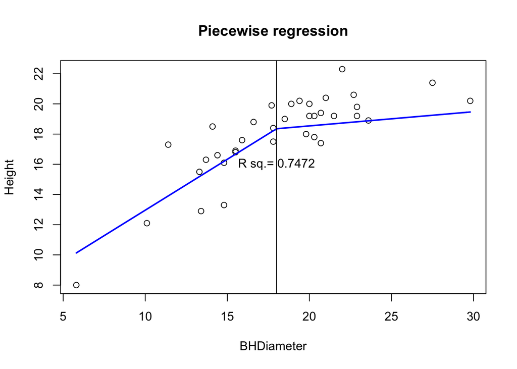

```r
curve(myf(x,coef=tmp$coefficients[,"Estimate"] ),add=TRUE, lwd=2,col="Blue")
abline(v=18)
text(18,16,paste("R sq.=",round(tmp$r.squared,4) ))
```